# El estado alimentico de los estudiantes de UTEC

## 3.4 Relación entre el N° de cursos con las horas de comida (desayuno, almuerzo y cena)

**Hora de desayuno**

```r
# para cambiar el orden
DC$H.Desayuno <- factor(DC$H.Desayuno, levels= c("5-6am","6-7am" ,"7-8am","8-9am","9-10am","10-11am","No suelo desayunar"))

table(DC$Curso,DC$H.Desayuno)
```

```
##
##     5-6am 6-7am 7-8am 8-9am 9-10am 10-11am No suelo desayunar
##   2     0     1     0     0      0       0                  0
##   3     0     0     1     2      1       1                  2
##   4     0     2     8    19      6       0                  0
##   5     1     4    12    14     18       0                  0
##   6     5    13    17    13      8       1                  2
##   7     2     3     8     3      4       2                  3
##   8     2     1     0     0      0       1                  0
```

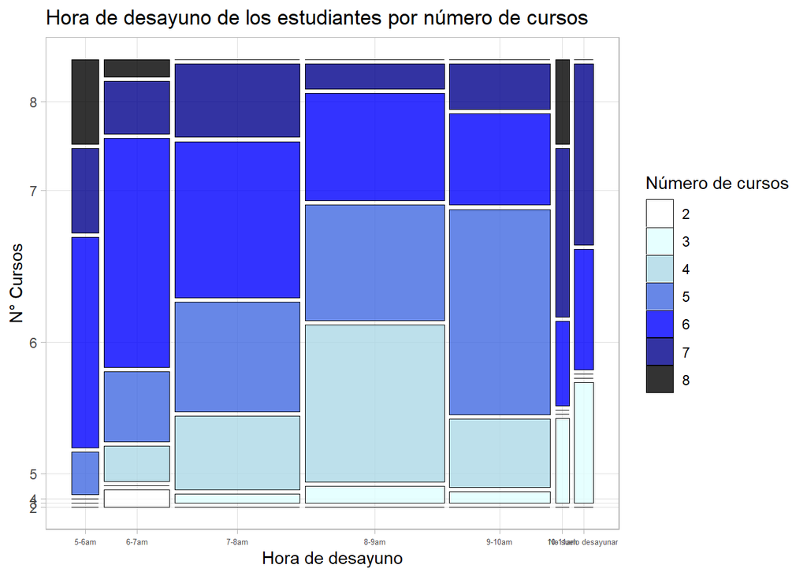

```r
ggplot(DC) +
  geom_mosaic(aes(x=product(Curso, H.Desayuno), fill=Curso, size = 1), color="black") +
  scale_fill_manual(values=c("white","lightcyan","lightblue","royalblue","blue","darkblue","black")) +
  labs(title="Hora de desayuno de los estudiantes por número de cursos",x="Hora de desayuno",y="N° Cursos", fill="Número de cursos") +
  theme_light() +
  theme(axis.text.x=element_text(size=5))
```

- La mayoría de estudiantes desayunan entre las siete y las nueve de la mañana,independientemente del número de cursos que estén tomando.
- La cantidad de estudiantes que desayunan disminuye a medida que el horario de desayuno se vuelve más temprano.
- Solo el 3.9% de estudiantes no desayunan.

**Hora de almuerzo**

```r
DC$H.Almuerzo <- factor(DC$H.Almuerzo, levels= c("11:00-12:00 PM","12:00-1:00 PM","1:00-2:00 PM","2:00-3:00 PM","3:00 a más","No suelo almorzar"))

table(DC$Curso,DC$H.Almuerzo)
```

```
##
##     11:00-12:00 PM 12:00-1:00 PM 1:00-2:00 PM 2:00-3:00 PM 3:00 a más
##   2              0             0            0            0          1
##   3              0             0            4            3          0
##   4              0             4           22            7          2
##   5              0             7           30           11          1
##   6              0            20           25            6          7
##   7              1             8            7            7          2
##   8              0             0            3            1          0
##
##     No suelo almorzar
##   2                 0
##   3                 0
##   4                 0
##   5                 0
##   6                 1
##   7                 0
##   8                 0
```

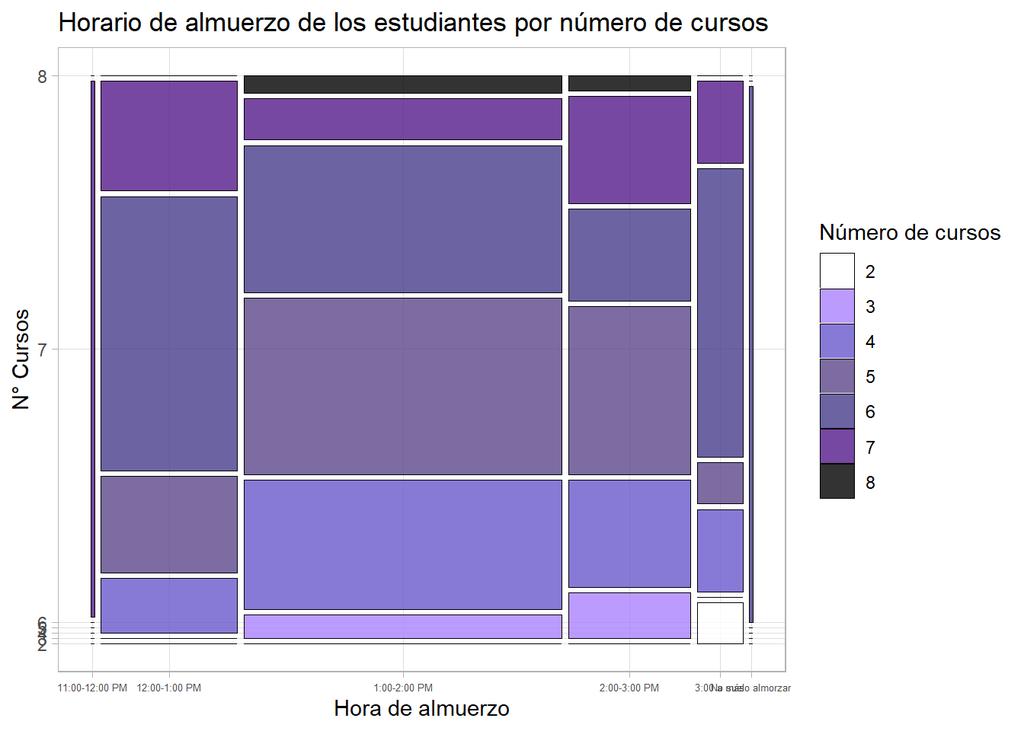

```r
ggplot(DC) +
  geom_mosaic(aes(x=product(Curso, H.Almuerzo), fill=Curso, size = 1), color="black") +
  scale_fill_manual(values=c("white","#AB82FF","#6959CD","#5D478B","#473C8B","#551A8B","black")) +
  labs(title="Horario de almuerzo de los estudiantes por número de cursos",x="Hora de almuerzo",y="N° Cursos", fill="Número de cursos") +
  theme_light() +
  theme(axis.text.x=element_text(size=5))#473C8B  #5D478B
```

- La mayoría de los estudiantes almuerzan entre la una y las dos de la tarde, independientemente del número de cursos que estén tomando.
- La cantidad de estudiantes que almuerzan aumentan a medida que el horario de almuerzo se vuelve más tarde hasta llegar a la una de la tarde, donde la relación comienza invertirse.

**Hora de cena**

```r
DC$H.Cena <- factor(DC$H.Cena, levels= c("6:00-7:00 PM","7:00-8:00 PM","8:00-9:00 PM","9:00-10:00 PM","10:00 a más","No suelo cenar"))

table(DC$Curso,DC$H.Cena)
```

```
##
##     6:00-7:00 PM 7:00-8:00 PM 8:00-9:00 PM 9:00-10:00 PM 10:00 a más
##   2            0            0            0             1           0
##   3            0            2            1             4           0
##   4            0            2            9            16           5
##   5            0            4           17            12           7
##   6            1            9           15            12           8
##   7            1            2            8             7           5
##   8            0            0            0             1           2
##
##     No suelo cenar
##   2              0
##   3              0
##   4              3
##   5              9
##   6             14
##   7              2
##   8              1
```

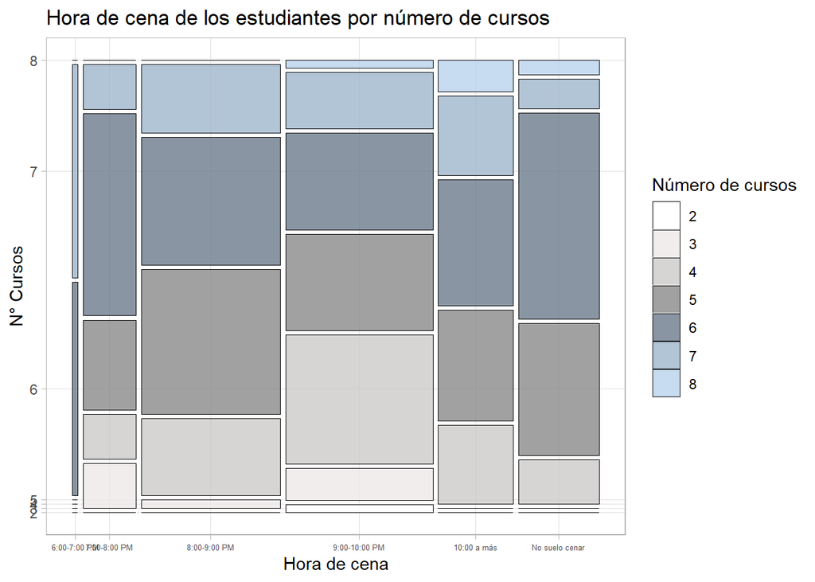

```r
ggplot(DC) +
  geom_mosaic(aes(x=product(Curso, H.Cena), fill=Curso, size = 1), color="black") +
  scale_fill_manual(values=c("white","#EEE9E9","#CDC9C9","#8B8989","#6C7B8B","#9FB6CD","slategray2")) +
  labs(title="Hora de cena de los estudiantes por número de cursos",x="Hora de cena",y="N° Cursos", fill="Número de cursos") +
  theme_light() +
  theme(axis.text.x=element_text(size=5))
```

- La mayoría de estudiantes cena entre las nueve y diez de la noche, independientemente del número de cursos que estén tomando.
- El número de estudiantes aumenta mientras más tarde es el horario de cena, hasta llegar a las nueve de la noche, donde después de las diez la relación comienza a invertirse.
- En esta etapa de almuerzo el 16.1% quiere decir 29 estudiantes no cenan.